# Course Project 2

This is the a descriptive document of the course project 2 (https://class.coursera.org/exdata-002). I have not followed the guidlines verbatim as my purpose was to avoid any R related problems and understand the concepts using the knowledge I have. I have strictly used ggplot2 package for plotting.

# Introduction

Fine particulate matter (PM2.5) is an ambient air pollutant for which there is strong evidence that it is harmful to human health. In the United States, the Environmental Protection Agency (EPA) is tasked with setting national ambient air quality standards for fine PM and for tracking the emissions of this pollutant into the atmosphere. Approximately every 3 years, the EPA releases its database on emissions of PM2.5. This database is known as the National Emissions Inventory (NEI). You can read more information about the NEI at the EPA National Emissions Inventory web site.

# Data Set

The data for this assignment are available from the course web site as a single zip file:

Data for Peer Assessment [29Mb] The zip file contains two files:

- fips: A five-digit number (represented as a string) indicating the U.S. county
- SCC: The name of the source as indicated by a digit string (see source code classification table)
- Pollutant: A string indicating the pollutant
- Emissions: Amount of PM2.5 emitted, in tons
- type: The type of source (point, non-point, on-road, or non-road)
- year: The year of emissions recorded

Source Classification Code Table (Source_Classification_Code.rds): This table provides a mapping from the SCC digit strings int he Emissions table to the actual name of the PM2.5 source. The sources are categorized in a few different ways from more general to more specific and you may choose to explore whatever categories you think are most useful. For example, source “10100101” is known as “Ext Comb /Electric Gen /Anthracite Coal /Pulverized Coal”

# Data Analysis

Steps

- Read in the RDS files given in the assignment.
- Use the normalize variable names function from rattle package to make the variable names into a standard format.
- Convert the pollutant and type variables from character data type to factors as it is used in the answering a few questions below.

```r
classificationData <- readRDS("exdata-data-NEI_data/Source_Classification_Code.rds")
emissionsData <- readRDS("exdata-data-NEI_data/summarySCC_PM25.rds")
names(emissionsData) <- normVarNames(names(emissionsData))
names(classificationData) <- normVarNames(names(classificationData))
emissionsData$pollutant <- factor(emissionsData$pollutant)
emissionsData$type <- factor(emissionsData$type)
# emissionsData$fips <- factor(emissionsData$fips)
```

- Get the summary of the data frames. Their variables, type and some values.
- Convert tbl_df from dplyr package to prevent the printing of a lot of data to the screen by accident.

```r
str(emissionsData)
```

```
## 'data.frame':    6497651 obs. of  6 variables:
##  $ fips     : chr  "09001" "09001" "09001" "09001" ...
##  $ scc      : chr  "10100401" "10100404" "10100501" "10200401" ...
##  $ pollutant: Factor w/ 1 level "PM25-PRI": 1 1 1 1 1 1 1 1 1 1 ...
##  $ emissions: num  15.714 234.178 0.128 2.036 0.388 ...
##  $ type     : Factor w/ 4 levels "NON-ROAD","NONPOINT",..: 4 4 4 4 4 4 4 4 4 4 ...
##  $ year     : int  1999 1999 1999 1999 1999 1999 1999 1999 1999 1999 ...
```

```r
emissionsData <- tbl_df(emissionsData)
str(classificationData)
```

```
## 'data.frame':    11717 obs. of  15 variables:
##  $ scc                : Factor w/ 11717 levels "10100101","10100102",..: 1 2 3 4 5 6 7 8 9 10 ...
##  $ data_category      : Factor w/ 6 levels "Biogenic","Event",..: 6 6 6 6 6 6 6 6 6 6 ...
##  $ short_name         : Factor w/ 11238 levels "","2,4-D Salts and Esters Prod /Process Vents, 2,4-D Recovery: Filtration",..: 3283 3284 3293 3291 3290 3294 3295 3296 3292 3289 ...
##  $ ei_sector          : Factor w/ 59 levels "Agriculture - Crops & Livestock Dust",..: 18 18 18 18 18 18 18 18 18 18 ...
##  $ option_group       : Factor w/ 25 levels "","C/I Kerosene",..: 1 1 1 1 1 1 1 1 1 1 ...
##  $ option_set         : Factor w/ 18 levels "","A","B","B1A",..: 1 1 1 1 1 1 1 1 1 1 ...
##  $ scc_level_one      : Factor w/ 17 levels "Brick Kilns",..: 3 3 3 3 3 3 3 3 3 3 ...
##  $ scc_level_two      : Factor w/ 146 levels "","Agricultural Chemicals Production",..: 32 32 32 32 32 32 32 32 32 32 ...
##  $ scc_level_three    : Factor w/ 1061 levels "","100% Biosolids (e.g., sewage sludge, manure, mixtures of these matls)",..: 88 88 156 156 156 156 156 156 156 156 ...
##  $ scc_level_four     : Factor w/ 6084 levels "","(NH4)2 SO4 Acid Bath System and Evaporator",..: 4455 5583 4466 4458 1341 5246 5584 5983 4461 776 ...
##  $ map_to             : num  NA NA NA NA NA NA NA NA NA NA ...
##  $ last_inventory_year: int  NA NA NA NA NA NA NA NA NA NA ...
##  $ created_date       : Factor w/ 57 levels "","1/27/2000 0:00:00",..: 1 1 1 1 1 1 1 1 1 1 ...
##  $ revised_date       : Factor w/ 44 levels "","1/27/2000 0:00:00",..: 1 1 1 1 1 1 1 1 1 1 ...
##  $ usage_notes        : Factor w/ 21 levels ""," ","includes bleaching towers, washer hoods, filtrate tanks, vacuum pump exhausts",..: 1 1 1 1 1 1 1 1 1 1 ...
```

## Problem 1

Have total emissions from PM2.5 decreased in the United States from 1999 to 2008? Make a plot showing the total PM2.5 emission from all sources for each of the years 1999, 2002, 2005, and 2008.

- Subset the emissions for each level in year and sum it.
- Because we compare the result of years, year is a ordinal variable. That is the reason I fill the bars with sequential color coding scheme.

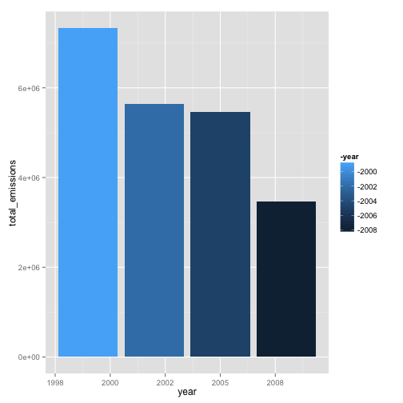

```r
totalYearwiseData <- emissionsData %.% select(pollutant, emissions, year) %.%
    group_by(year) %.% summarise(total_emissions = sum(emissions))
totalYearwiseData <- as.data.frame(totalYearwiseData)


p1 <- ggplot(data = totalYearwiseData, aes(x = year, y = total_emissions))
p1 + geom_bar(stat = "identity", aes(fill = -year))
```

Answer: Yes it has been declining from 1999 to 2008.

## Problem 2

Have total emissions from PM2.5 decreased in the Baltimore City, Maryland (fips == “24510”) from 1999 to 2008?

- Subset of the data using the filter() from dplyr to contain data of Baltimore City only; using the fips given.

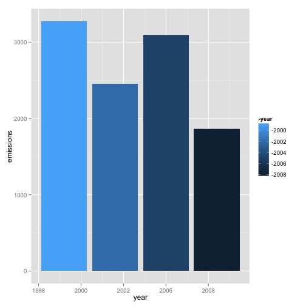

```r
BaltimoreData <- filter(emissionsData, fips == "24510")

p2 <- ggplot(data = BaltimoreData, aes(x = year, y = emissions))
p2 <- p2 + geom_bar(stat = "identity", aes(fill = -year))
p2
```

Answer: Overall yes it has decreased but there was a spike in 2005 unlike the overall trend shown in the previous plot for entire country.

## Problem 3

Of the four types of sources indicated by the type (point, nonpoint, onroad, nonroad) variable, which of these four sources have seen decreases in emissions from 1999–2008 for Baltimore City? Which have seen increases in emissions from 1999–2008? Use the ggplot2 plotting system to make a plot answer this question.

- Use Facetting to create plots for each level of type factor variable.

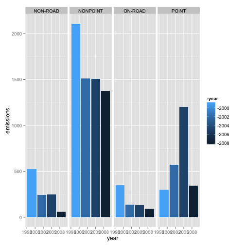

```r
p3 <- p2 + facet_grid(. ~ type)
p3
```

Answer: This reveals many different aspects of the pollution due to the types of sources. Non-point contribute the most to the pollution in Baltimore. Point source pollution has not decreased over the years which is an exception to all the other type of the sources.

## Problem 4

Across the United States, how have emissions from coal combustion-related sources changed from 1999–2008?

To answer this I create a data set with left outer join if the the two data frames.

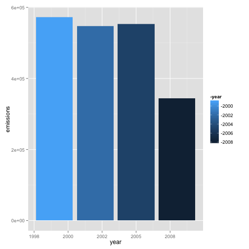

```r
completeData <- merge(x = emissionsData, y = classificationData, by = "scc",
    all.x = T)

coalDataSet <- filter(completeData, str_detect(completeData$ei_sector, "* Coal"))

p4 <- ggplot(data = coalDataSet, aes(x = year, y = emissions))
p4 <- p4 + geom_bar(stat = "identity", aes(fill = -year))
p4
```

Answer: Has been on a decline recently and not so much before.

## Problem 5

How have emissions from motor vehicle sources changed from 1999–2008 in Baltimore City?

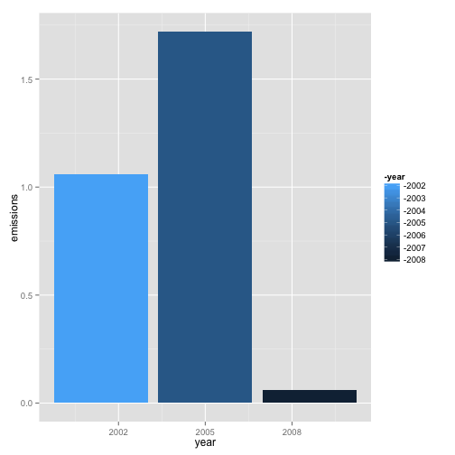

```r
vehiclesBaltimoreData <- completeData %.% filter(fips == "24510") %.% filter(scc_level_one ==
    "Internal Combustion Engines")

p5 <- ggplot(data = vehiclesBaltimoreData, aes(x = year, y = emissions))
p5 <- p5 + geom_bar(stat = "identity", aes(fill = -year))
p5
```

## Problem 6

Compare emissions from motor vehicle sources in Baltimore City with emissions from motor vehicle sources in Los Angeles County, California (fips == “06037”). Which city has seen greater changes over time in motor vehicle emissions?

- Use the same technique as previously, just add an or condition to accept Los Angeles data as well.

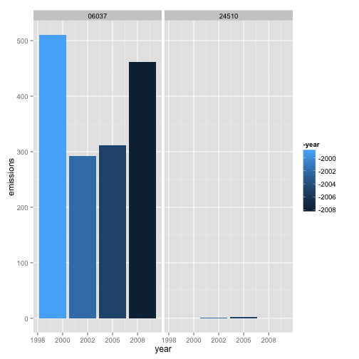

```r
vehicles2CitiesData <- completeData %.% filter(fips == "24510" | fips == "06037") %.%
    filter(scc_level_one == "Internal Combustion Engines")

p6 <- ggplot(data = vehicles2CitiesData, aes(x = year, y = emissions))
p6 <- p6 + geom_bar(stat = "identity", aes(fill = -year)) + facet_grid(. ~ fips)
p6
```

Answer: L.A. has much more motor vehicular pollution as compared to Baltimore city. And lately it has been on rise in L.A. which is not a good sign either.